# ML Algorithms for classification

Decision trees

Hicham Zmarrou

Notebook – http://bit.ly/2q9NPSU

[Visit my website](http://trefoil.ml/) for more like this!

**References**

Most of this material is borrowed from:

- Textbook: [Introduction to statistical learning](http://www-bcf.usc.edu/~gareth/ISL/)

First let’s define a problem. There’s a common scam amongst motorists where a person will slam on his breaks in heavy traffic with the intention of being rear-ended. The person will then file an insurance claim for personal injury and damage to his vehicle, alleging that the other driver was at fault. Suppose we want to predict which of an insurance company’s claims are fraudulent using a decision tree. To start, we need to build a training set of known fraudulent claims.

```r
train <- data.frame(ClaimID = c(1,2,3),
                    RearEnd = c(TRUE, FALSE, TRUE),
                    Fraud = c(TRUE, FALSE, TRUE))
train
```

| ClaimID | RearEnd | Fraud |
| --- | --- | --- |
| 1 | TRUE | TRUE |
| 2 | FALSE | FALSE |
| 3 | TRUE | TRUE |

In order to grow our decision tree, we have first to load the rpart package. Then we can use the function rpart(), specifying the model formula, data, and method parameters. In this case, we want to classify the feature Fraud using the predictor RearEnd, so our call to rpart should look like

```r
library(rpart) #load the rpart package

mytree <- rpart(Fraud ~ RearEnd, data = train, method = "class")
mytree
```

[output not shown]

```r
mytree <- rpart(Fraud ~ RearEnd, data = train, method = "class", minsplit = 2, minbucket = 1)
mytree
```

```
n= 3

node), split, n, loss, yval, (yprob)
      * denotes terminal node

1) root 3 1 TRUE (0.3333333 0.6666667)
  2) RearEnd< 0.5 1 0 FALSE (1.0000000 0.0000000) *
  3) RearEnd>=0.5 2 0 TRUE (0.0000000 1.0000000) *
```

Now our tree has a root node, one split and two leaves (terminal nodes). Observe that rpart encoded our boolean variable as an integer (False = 0, True = 1). We can plot mytree by loading the rattle package (and some helper packages) and using the fancyRpartPlot() function.

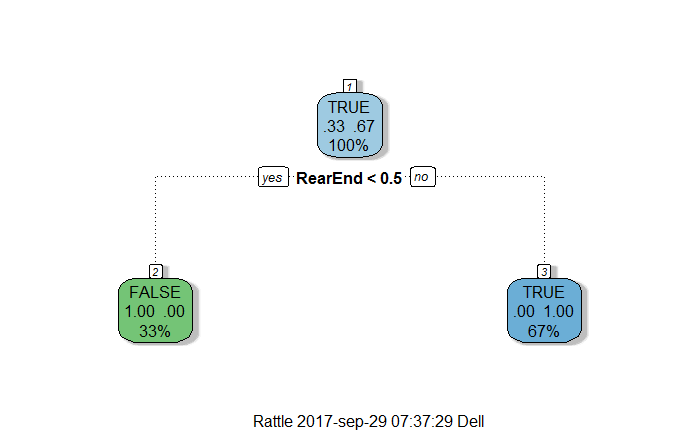

```r
library(rattle)
library(rpart.plot)
library(RColorBrewer)

fancyRpartPlot(mytree)
```

By default, rpart uses gini impurty to select splits when performing classification. You can use information gain instead by specifying it in the parms parameter.

```r
mytree <- rpart(Fraud ~ RearEnd, data = train, method = "class",
                parms = list(split = 'information'), minsplit = 2, minbucket = 1)
```

Now suppose our training set looked like

```r
train <- data.frame(ClaimID = c(1,2,3),
                    RearEnd = c(TRUE, FALSE, TRUE),
                    Fraud = c(TRUE, FALSE, FALSE))
train
```

| ClaimID | RearEnd | Fraud |
| --- | --- | --- |
| 1 | TRUE | TRUE |
| 2 | FALSE | FALSE |
| 3 | TRUE | FALSE |

If we try to build a decision tree on this data

```r
mytree <- rpart(Fraud ~ RearEnd, data = train, method = "class", minsplit = 2, minbucket = 1)
mytree
```

```
n= 3

node), split, n, loss, yval, (yprob)
      * denotes terminal node

1) root 3 1 FALSE (0.6666667 0.3333333) *
```

Once again we’re left with just a root node. Internally, rpart keeps track of something called the complexity of a tree. The complexity measure is a combination of the size of a tree and the ability of the tree to separate the classes of the target variable. If the next best split in growing a tree does not reduce the tree’s overall complexity by a certain amount, rpart will terminate the growing process. This amount is specified by the complexity parameter, cp, in the call to rpart. Setting cp to a negative amount ensures that the tree will be fully grown.

```r
mytree <- rpart(Fraud ~ RearEnd, data = train, method = "class", minsplit = 2, minbucket = 1, cp=-1)
fancyRpartPlot(mytree)
```

[output not shown]

This is not always a good idea since it will typically produce over-fitted trees, but trees can be pruned back as discussed later. You can also weight each observation for the tree’s construction by specifying the weights argument to rpart.

```r
mytree <- rpart(Fraud ~ RearEnd, data = train, method = "class", minsplit = 2, minbucket = 1,
                weights = c(.4, .4, .2))
fancyRpartPlot(mytree)
```

[output not shown]

One of the best ways to identify a fraudulent claim is to hire a private investigator to monitor the activities of a claimant. Since private investigators don’t work for free, the insurance company will have to strategically decide which claims to investigate. To do this, they can use a decision tree model based off some initial features of the claim. If the insurance company wants to aggressively investigate claims (i.e. investigate a lot of claims), they can train their decision tree in a manner that will penalize incorrectly labeled fraudulent claims more than it penalizes incorrectly labeled non-fraudulent claims. To alter the default, equal penalization of mislabeled target classes set the loss component of the parms parameter to a matrix where the (i,j) element is the penalty for misclassifying an i as a j. (The loss matrix must have 0s in the diagonal). For example, consider the following training data.

```r
train <- data.frame(ClaimID = c(1,2,3,4,5,6,7),
                    RearEnd = c(TRUE, TRUE, FALSE, FALSE, FALSE, FALSE, FALSE),
                    Whiplash = c(TRUE, TRUE, TRUE, TRUE, TRUE, FALSE, FALSE),
                    Fraud = c(TRUE, TRUE, TRUE, FALSE, FALSE, FALSE, FALSE))
train
```

| ClaimID | RearEnd | Whiplash | Fraud |
| --- | --- | --- | --- |
| 1 | TRUE | TRUE | TRUE |
| 2 | TRUE | TRUE | TRUE |
| 3 | FALSE | TRUE | TRUE |
| 4 | FALSE | TRUE | FALSE |
| 5 | FALSE | TRUE | FALSE |
| 6 | FALSE | FALSE | FALSE |
| 7 | FALSE | FALSE | FALSE |

Now let’s grow our decision tree, restricting it to one split by setting the maxdepth argument to 1.

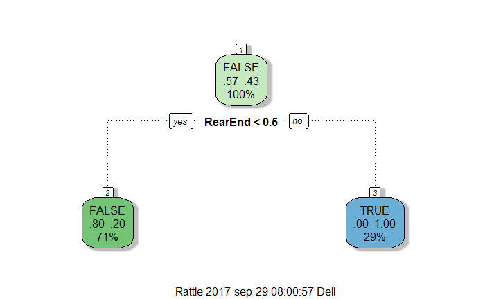

```r
mytree <- rpart(Fraud ~ RearEnd + Whiplash, data = train, method = "class",
                maxdepth = 1, minsplit = 2, minbucket = 1)
fancyRpartPlot(mytree)
```

rpart has determined that RearEnd was the best variable for identifying a fraudulent claim. BUT there was one fraudulent claim in the training set that was not the case of a rear-end collision. If the insurance company wants to identify a high percentage of fraudulent claims without worrying too much about investigating non-fraudulent claims they can set the loss matrix to penalize claims incorrectly labeled as fraudulent three times less than claims incorrectly labeled as non-fraudulent.

```r
lossmatrix <- matrix(c(0,1,3,0), byrow=TRUE, nrow=2)
lossmatrix
```

```
     [,1] [,2]
[1,]    0    1
[2,]    3    0
```

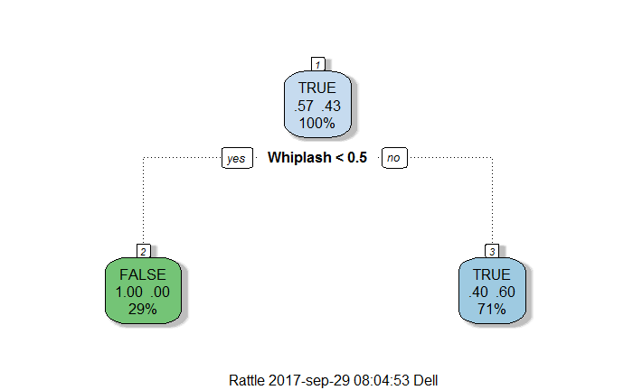

```r
mytree <- rpart(Fraud ~ RearEnd + Whiplash, data = train, method = "class",
                maxdepth = 1, minsplit = 2, minbucket = 1,
                parms = list(loss = lossmatrix))
fancyRpartPlot(mytree)
```

Now our model suggests that Whiplash is the best vairable to identify fraudulent claims.

Now let’s see how rpart interacts with factor variables. Suppose the insurance company hires an investigator to assess the activity level of claimants. Activity levels can be Very Active, Active, Inactive, or Very Inactive.

```r
train <- data.frame(ClaimID = c(1,2,3,4,5),
                    Activity = factor(c("active", "very active", "very active", "inactive", "very inactive"),
                                      levels=c("very inactive", "inactive", "active", "very active")),
                    Fraud = c(FALSE, TRUE, TRUE, FALSE, TRUE))
train
```

| ClaimID | Activity | Fraud |
| --- | --- | --- |
| 1 | active | FALSE |
| 2 | very active | TRUE |
| 3 | very active | TRUE |
| 4 | inactive | FALSE |
| 5 | very inactive | TRUE |

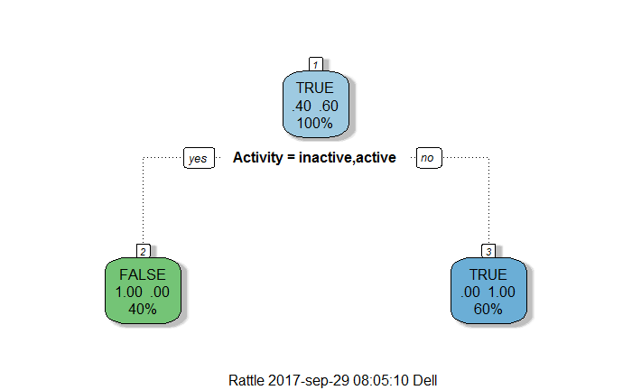

```r
mytree <- rpart(Fraud ~ Activity, data = train, method = "class", minsplit = 2, minbucket = 1)
fancyRpartPlot(mytree)
```

Another dataset

```r
train <- data.frame(ClaimID = c(1,2,3,4,5),
                    Activity = factor(c("active", "very active", "very active", "inactive", "very inactive"),
                                      levels=c("very inactive", "inactive", "active", "very active"),
                                      ordered=TRUE),
                    Fraud = c(FALSE, TRUE, TRUE, FALSE, TRUE))
train
```

| ClaimID | Activity | Fraud |
| --- | --- | --- |
| 1 | active | FALSE |
| 2 | very active | TRUE |
| 3 | very active | TRUE |
| 4 | inactive | FALSE |
| 5 | very inactive | TRUE |

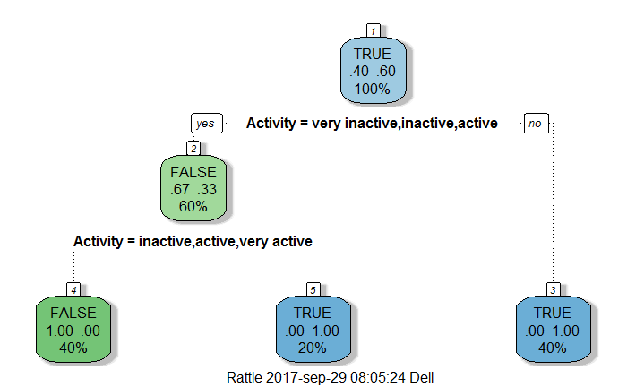

```r
mytree <- rpart(Fraud ~ Activity, data = train, method = "class", minsplit = 2, minbucket = 1)
fancyRpartPlot(mytree)
```

In the first dataset, we did not specify that the Activity vector was an ordered factor, so rpart tested every possible way to split the levels of the Activity vector. In the second dataset, Activity was specified as an ordered factor so rpart only tested splits that separated the ordered set of Activity levels. (For more explanation of this, see [this post](https://gormanalysis.com/magic-behind-constructing-a-decision-tree/)) It’s usually a good idea to prune a decision tree. Fully grown trees don’t perform well against data not in the training set because they tend to be overfitted so pruning is used to reduce their complexity by keeping only the most important splits.

```r
#Build a training set
train <- data.frame(ClaimID = c(1,2,3,4,5,6,7,8,9,10),
                    RearEnd = c(TRUE, TRUE, TRUE, FALSE, FALSE, FALSE, FALSE, TRUE, TRUE, FALSE),
                    Whiplash = c(TRUE, TRUE, TRUE, TRUE, TRUE, FALSE, FALSE, FALSE, FALSE, TRUE),
                    Activity = factor(c("active", "very active", "very active", "inactive", "very inactive", "inactive", "very inactive", "active", "active", "very active"),
                                      levels=c("very inactive", "inactive", "active", "very active"),
                                      ordered=TRUE),
                    Fraud = c(FALSE, TRUE, TRUE, FALSE, FALSE, TRUE, TRUE, FALSE, FALSE, TRUE))
train
```

| ClaimID | RearEnd | Whiplash | Activity | Fraud |
| --- | --- | --- | --- | --- |
| 1 | TRUE | TRUE | active | FALSE |
| 2 | TRUE | TRUE | very active | TRUE |
| 3 | TRUE | TRUE | very active | TRUE |
| 4 | FALSE | TRUE | inactive | FALSE |
| 5 | FALSE | TRUE | very inactive | FALSE |
| 6 | FALSE | FALSE | inactive | TRUE |
| 7 | FALSE | FALSE | very inactive | TRUE |
| 8 | TRUE | FALSE | active | FALSE |
| 9 | TRUE | FALSE | active | FALSE |
| 10 | FALSE | TRUE | very active | TRUE |

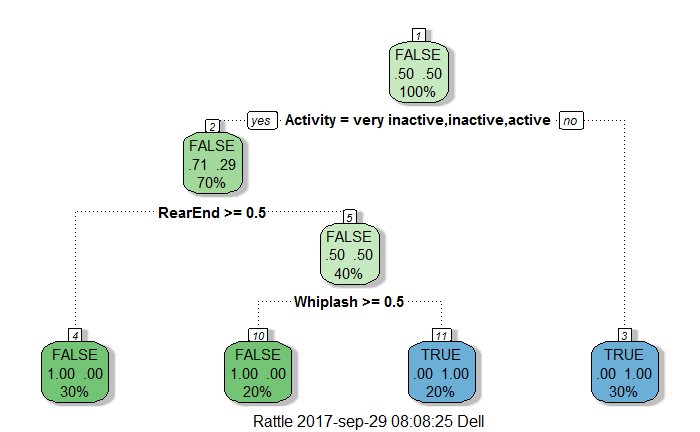

```r
#Grow a full tree
mytree <- rpart(Fraud ~ RearEnd + Whiplash + Activity, data = train, method = "class", minsplit = 2, minbucket = 1, cp=-1)
fancyRpartPlot(mytree)
```

You can view the importance of each variable in the model by calling the variable.importance attribute of the resulting rpart object. From the rpart documentation, “An overall measure of variable importance is the sum of the goodness of split measures for each split for which it was the primary variable.

```r
mytree$variable.importance
```

[output not shown]

When rpart grows a tree it performs 10-fold cross validation on the data. To see the cross validation results use the printcp() function.

```r
printcp(mytree)
```

[output not shown]

```r
mytree <- prune(mytree, cp=.21)
fancyRpartPlot(mytree)
```

[output not shown]

From here we can use our decision tree to predict fraudulent claims on an unseen dataset using the predict() function.

```r
test <- data.frame(ClaimID = c(1,2,3,4,5,6,7,8,9,10),
                    RearEnd = c(FALSE, TRUE, TRUE, FALSE, FALSE, FALSE, FALSE, TRUE, TRUE, FALSE),
                    Whiplash = c(FALSE, TRUE, TRUE, TRUE, TRUE, FALSE, FALSE, FALSE, FALSE, TRUE),
                    Activity = factor(c("inactive", "very active", "very active", "inactive", "very inactive", "inactive", "very inactive", "active", "active", "very active"),
                                      levels=c("very inactive", "inactive", "active", "very active"),
                                      ordered=TRUE))
test


test$FraudClass <- predict(mytree, newdata = test, type="class") #Returns the predicted class
test$FraudProb <- predict(mytree, newdata = test, type="prob") #Returns a matrix of predicted probabilities

test
```

[output not shown]

In summary, the rpart package is a godd. I tried to cover the most important features of the package, but I suggest you read through the rpart vignette to understand the things I skipped.